# Using temperature to describe stress

Mikaela M. Provost

7/2/2020

## Goals

Focus on one site around Natividad, Punta Prieta. Goal is to test different temperature-related methods of defining stress based on the literature.

Data:

- Temperature observations are every 10 minutes, April-November 2018.
- Daily temp for a longer period of time (2009-2019).

Typical estimates of stress count the number of days observed above X degree. This doesn’t account for how fast temperatures change. I explore a couple methods that try to account for temperature variability because this is probably important in causing stress in abalone.

## Rolling window of temperature variability

Temperature time series is transformed into one value per day to represent day-by-day ‘stress’ level. Since abalone are sensitive to temperature variability in short term (~24 hr) (Boch et al. 2018, Vosloo and Vosloo 2010, Tae-Hyung et al. 2006, Calderon-Lievanos et al. 2019), we quantify temperature variation experienced in the most recent 2 days.

I’ve found little evidence in the literature that explores the effect of temperature variability experienced over long time periods (1 month or longer, for example) on abalone stress. But there is some evidence on the short-term effects of temperature variability.

- temperature variation of ~4 standard deviations over 24-48 hours causes noticable stress (Boch et al. 2018)
- abalone can adapt to warmer than usual temperature if it is chronic exposure (1 month exposure). But not if it is acute (exposure over 24 hr) (Vosloo and Vosloo 2010)
- physiological changes occur within 24 hours of exposure, but can start to recover after 48 hours of exposure (Tae-Hyung et al. 2006)
- even though short-term events are less likely to cause mass mortalities than extreme events that last several days, there is still an effect of temperature on survival without the synergistic effects of oxygen and ph in the short term.
  - temperature matters more for survival in the short term (first 24 hr exposure to extremes) than hypoxia.
  - but in the long term (96 hr of exposure) hypoxia affects survival more than temperature.
  - synergistic effect of temp and hypoxia on survival increases in first 24; consistently mattered after 48 hr exposure (Calderon-Lievanos et al. 2019)

Considering all this, I calculate the standard deviation of temperature variation over the previous 2 days.

**Important:** need to identify the standard deviation threshold associated with very high stress. (for example, sd=4). Then we can identify the frequency of such events.

Here is temperature at Punta Prieta in April-Nov 2018. Grey dots = temperature at 10 min intervals. Black line = mean daily temperature. Red dashed line = 20 deg C.

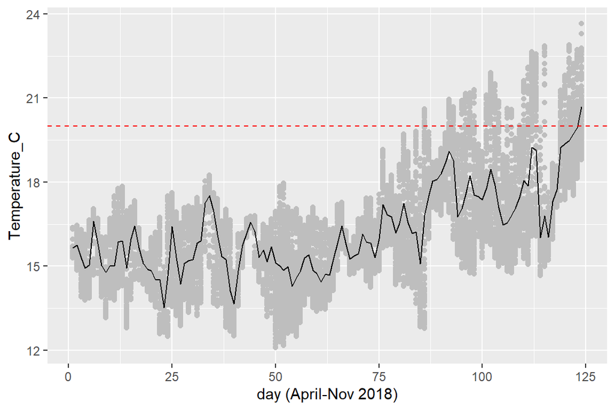

Here is temperature at Punta Prieta 2009-2019. Grey line = daily SST from satelites. Red line = 20 deg C.

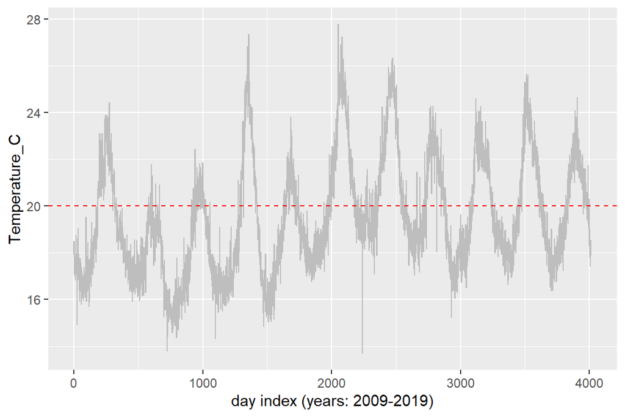

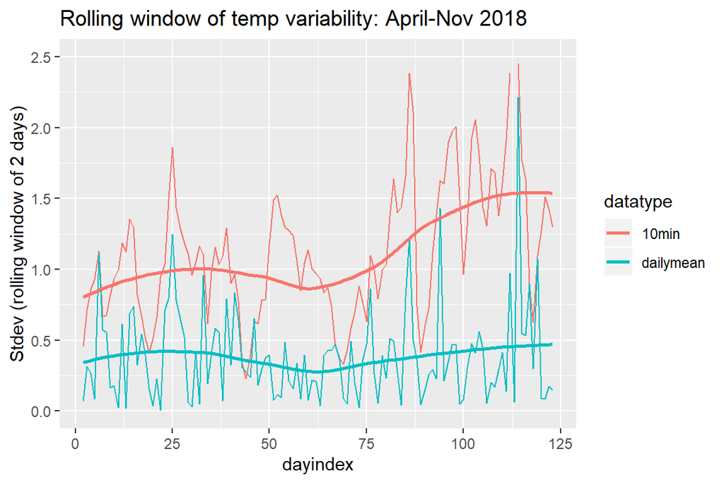

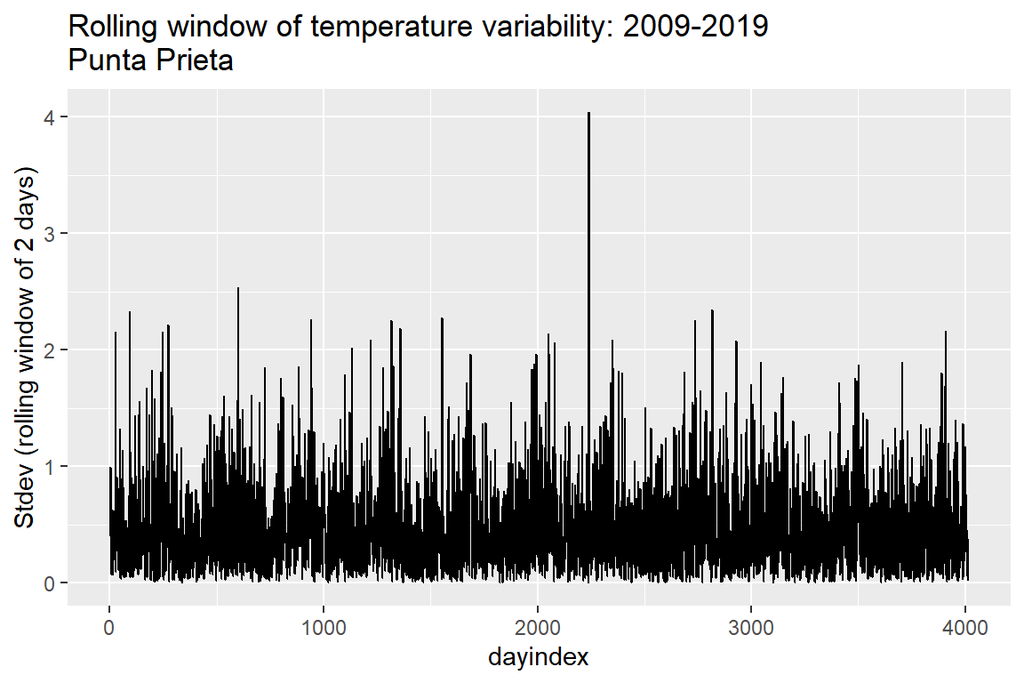

## Extreme Events

- Fraction of 10 minute intervals in April-Nov 2018 that were >20 = 0.05
- Fraction of days in April-Nov 2018 that were >20 = 0.01
- Fraction of days in 2009-2019 >20 = 0.38

How long do extreme events last in the 10 minute interval temperature data? How many extreme events were there in April-Nov 2018?

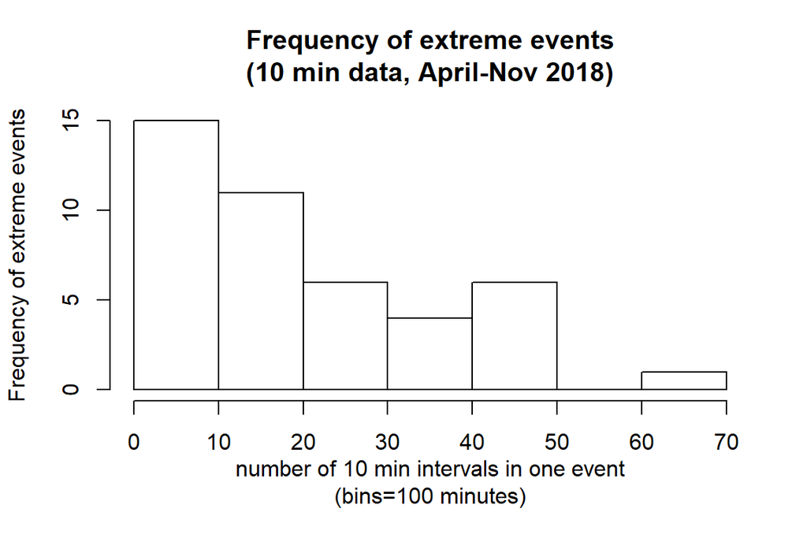

How long do extreme events last when temperature data is averaged per day? How many extreme events?

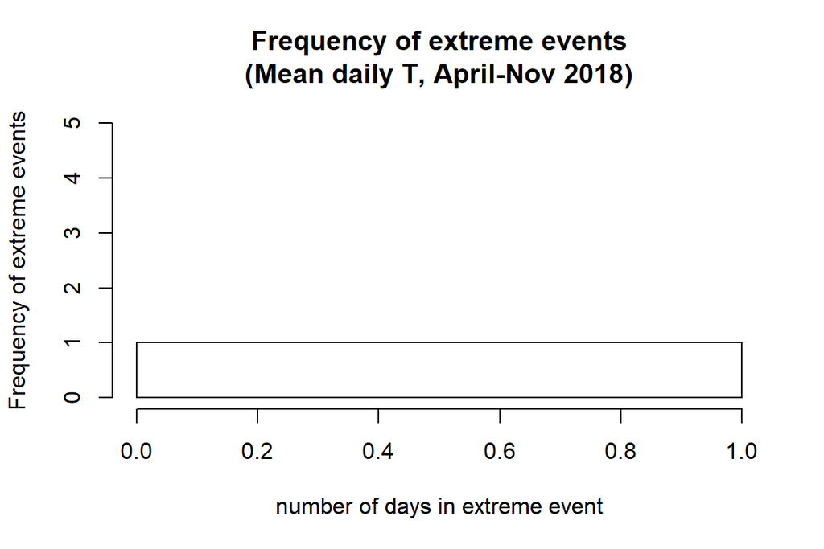

How many extreme events at Punta Prieta between 2009-2019? How long did they last?

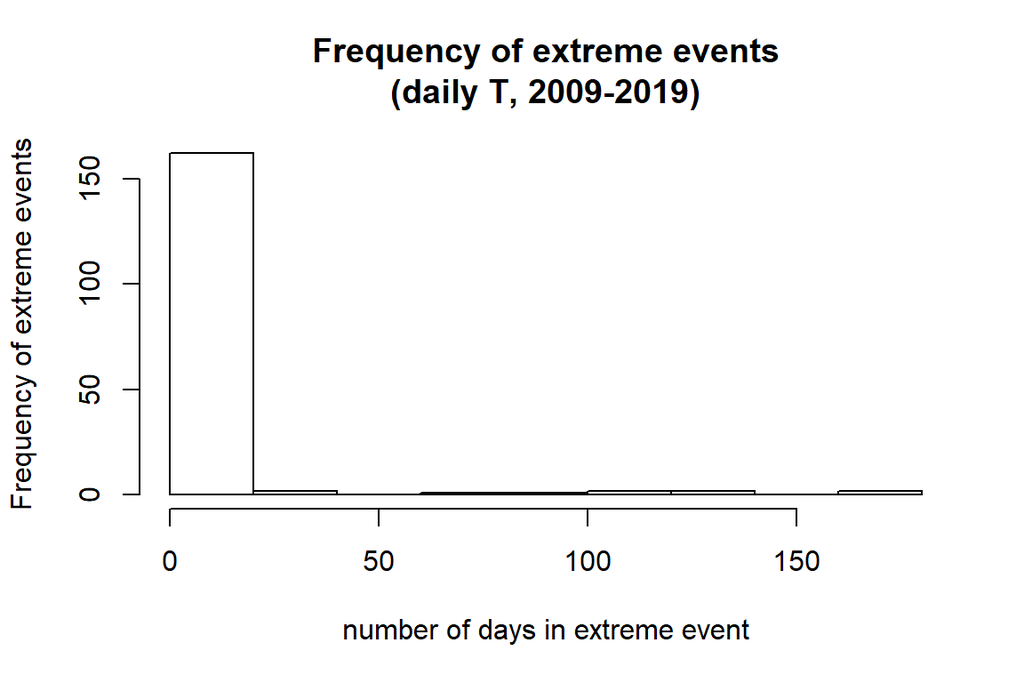

## References

Boch, C. A., Micheli, F., AlNajjar, M., Monismith, S. G., Beers, J. M., Bonilla, J. C., … & Woodson, C. B. (2018). Local oceanographic variability influences the performance of juvenile abalone under climate change. Scientific reports, 8(1), 1-12.

Samuel, Calderón-Liévanos, Hernández-Saavedra Norma Yolanda, Lluch-Cota Salvador Emilio, Cruz-Hernández Pedro, Ascencio-Valle Felipe De Jesús, and Sicard María Teresa. “Survival and respiration of green abalone (Haliotis fulgens) facing very short-term marine environmental extremes.” Marine and Freshwater Behaviour and Physiology 52, no. 1 (2019): 1-15.

Kim, T. H., Kim, K. J., Choe, M. K., & Yeo, I. K. (2006). Physiological changes of juvenile abalone, Haliotis sieboldii exposed to acute water-temperature stress. Journal of Aquaculture, 19(2), 77-83.

Vosloo, Daléne, and André Vosloo. “Response of cold-acclimated, farmed South African abalone (Haliotis midae) to short-term and long-term changes in temperature.” Journal of Thermal Biology 35.7 (2010): 317-323.